# Problem Statement

The purpose is to predict whether the Pima Indian women shows signs of diabetes or not. We are using a dataset collected by "National Institute of Diabetes and Digestive and Kidney Diseases" which consists of a number of attributes which would help us to perform this prediction.

**Constraints on data collection**

All patients whose data has been collected are females at least 21 years old of Pima Indian heritage

```python
#Import all the necessary modules
import pandas as pd
from sklearn.tree import DecisionTreeClassifier

#importing seaborn for statistical plots
import seaborn as sns

#Let us break the X and y dataframes into training set and test set. For this we will use
#Sklearn package's data splitting function which is based on random function

from sklearn.model_selection import train_test_split

import numpy as np

# calculate accuracy measures and confusion matrix
from sklearn import metrics

%matplotlib inline
```

# Q1. Load the PIMA Indian Diabetes file into Python DataFrame.

The file can be accessed directly from the URL (https://archive.ics.uci.edu/ml/machine-learning-databases/pima-indians-diabetes/pima-indians-diabetes.data or you may first download it to a local folder and then load it into Python dataframe. Let us assume the data frame is named pima_df

```python
pima_df = pd.read_csv("Diabetes1.csv")
```

# Q2. Print 10 samples from the dataset

```python
pima_df.head(10)
```

|  | Pregnancies | Glucose | BloodPressure | SkinThickness | Insulin | BMI | DiabetesPedigreeFunction | Age | Outcome |
| --- | --- | --- | --- | --- | --- | --- | --- | --- | --- |
| 0 | 6 | 148 | 72 | 35 | 0 | 33.6 | 0.627 | 50 | 1 |
| 1 | 1 | 85 | 66 | 29 | 0 | 26.6 | 0.351 | 31 | 0 |
| 2 | 8 | 183 | 64 | 0 | 0 | 23.3 | 0.672 | 32 | 1 |
| 3 | 1 | 89 | 66 | 23 | 94 | 28.1 | 0.167 | 21 | 0 |
| 4 | 0 | 137 | 40 | 35 | 168 | 43.1 | 2.288 | 33 | 1 |
| 5 | 5 | 116 | 74 | 0 | 0 | 25.6 | 0.201 | 30 | 0 |
| 6 | 3 | 78 | 50 | 32 | 88 | 31.0 | 0.248 | 26 | 1 |
| 7 | 10 | 115 | 0 | 0 | 0 | 35.3 | 0.134 | 29 | 0 |
| 8 | 2 | 197 | 70 | 45 | 543 | 30.5 | 0.158 | 53 | 1 |
| 9 | 8 | 125 | 96 | 0 | 0 | 0.0 | 0.232 | 54 | 1 |

# Q3 Print the datatypes of each column and the shape of the dataset

```python
pima_df.info()
```

```
<class 'pandas.core.frame.DataFrame'>
RangeIndex: 768 entries, 0 to 767
Data columns (total 9 columns):
Pregnancies                 768 non-null int64
Glucose                     768 non-null int64
BloodPressure               768 non-null int64
SkinThickness               768 non-null int64
Insulin                     768 non-null int64
BMI                         768 non-null float64
DiabetesPedigreeFunction    768 non-null float64
Age                         768 non-null int64
Outcome                     768 non-null int64
dtypes: float64(2), int64(7)
memory usage: 54.1 KB
```

There are '0's in the data. Are they really valid '0's or they are missing values? Plasma, BP, skin thickness etc. these values cannot be 0. look at column by column logically to understand this.

# Q4 Replace all the 0s in the column with the median of the same column value accordingly.

```python
pima_df[~pima_df.applymap(np.isreal).all(1)]
```

|  | Pregnancies | Glucose | BloodPressure | SkinThickness | Insulin | BMI | DiabetesPedigreeFunction | Age | Outcome |
| --- | --- | --- | --- | --- | --- | --- | --- | --- | --- |

```python
#pima_df = pima_df.fillna(pima_df.median())
cols = pima_df.columns
```

```python
for a in cols[1:8]:
    pima_df[a]=pima_df[a].replace(0,pima_df[a].median())

pima_df.head(10)
```

|  | Pregnancies | Glucose | BloodPressure | SkinThickness | Insulin | BMI | DiabetesPedigreeFunction | Age | Outcome |
| --- | --- | --- | --- | --- | --- | --- | --- | --- | --- |
| 0 | 6 | 148 | 72 | 35 | 30.5 | 33.6 | 0.627 | 50 | 1 |
| 1 | 1 | 85 | 66 | 29 | 30.5 | 26.6 | 0.351 | 31 | 0 |
| 2 | 8 | 183 | 64 | 23 | 30.5 | 23.3 | 0.672 | 32 | 1 |
| 3 | 1 | 89 | 66 | 23 | 94.0 | 28.1 | 0.167 | 21 | 0 |
| 4 | 0 | 137 | 40 | 35 | 168.0 | 43.1 | 2.288 | 33 | 1 |
| 5 | 5 | 116 | 74 | 23 | 30.5 | 25.6 | 0.201 | 30 | 0 |
| 6 | 3 | 78 | 50 | 32 | 88.0 | 31.0 | 0.248 | 26 | 1 |
| 7 | 10 | 115 | 72 | 23 | 30.5 | 35.3 | 0.134 | 29 | 0 |
| 8 | 2 | 197 | 70 | 45 | 543.0 | 30.5 | 0.158 | 53 | 1 |
| 9 | 8 | 125 | 96 | 23 | 30.5 | 32.0 | 0.232 | 54 | 1 |

# Q5 Print the descriptive statistics of each & every column using describe() function

```python
pima_df.describe().transpose()
```

|  | count | mean | std | min | 25% | 50% | 75% | max |
| --- | --- | --- | --- | --- | --- | --- | --- | --- |
| Pregnancies | 768.0 | 3.845052 | 3.369578 | 0.000 | 1.00000 | 3.0000 | 6.00000 | 17.00 |
| Glucose | 768.0 | 121.656250 | 30.438286 | 44.000 | 99.75000 | 117.0000 | 140.25000 | 199.00 |
| BloodPressure | 768.0 | 72.386719 | 12.096642 | 24.000 | 64.00000 | 72.0000 | 80.00000 | 122.00 |
| SkinThickness | 768.0 | 27.334635 | 9.229014 | 7.000 | 23.00000 | 23.0000 | 32.00000 | 99.00 |
| Insulin | 768.0 | 94.652344 | 105.547598 | 14.000 | 30.50000 | 31.2500 | 127.25000 | 846.00 |
| BMI | 768.0 | 32.450911 | 6.875366 | 18.200 | 27.50000 | 32.0000 | 36.60000 | 67.10 |
| DiabetesPedigreeFunction | 768.0 | 0.471876 | 0.331329 | 0.078 | 0.24375 | 0.3725 | 0.62625 | 2.42 |
| Age | 768.0 | 33.240885 | 11.760232 | 21.000 | 24.00000 | 29.0000 | 41.00000 | 81.00 |
| Outcome | 768.0 | 0.348958 | 0.476951 | 0.000 | 0.00000 | 0.0000 | 1.00000 | 1.00 |

# Q6 See the distribution of 'Class' variable and plot it using appropriate graph.

```python
#Since there is no 'Class' variable, I have used the Outcome variable
pima_df.groupby(["Outcome"]).count()
```

| Outcome | Pregnancies | Glucose | BloodPressure | SkinThickness | Insulin | BMI | DiabetesPedigreeFunction | Age |
| --- | --- | --- | --- | --- | --- | --- | --- | --- |
| 0 | 500 | 500 | 500 | 500 | 500 | 500 | 500 | 500 |
| 1 | 268 | 268 | 268 | 268 | 268 | 268 | 268 | 268 |

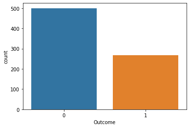

```python
sns.countplot(pima_df['Outcome'])
```

# Just for your understanding - Using univariate analysis check the individual attributes for their basic statistic such as central values, spread, tails etc. What are your observations (any two attributes). Its an optional step and will not be graded.

# Q7. Use pairplots and correlation method to observe the relationship between different variables and state your insights.

Hint: Use seaborn plot and check the relationship between different variables

Using the plot - infer the relationship between different variables

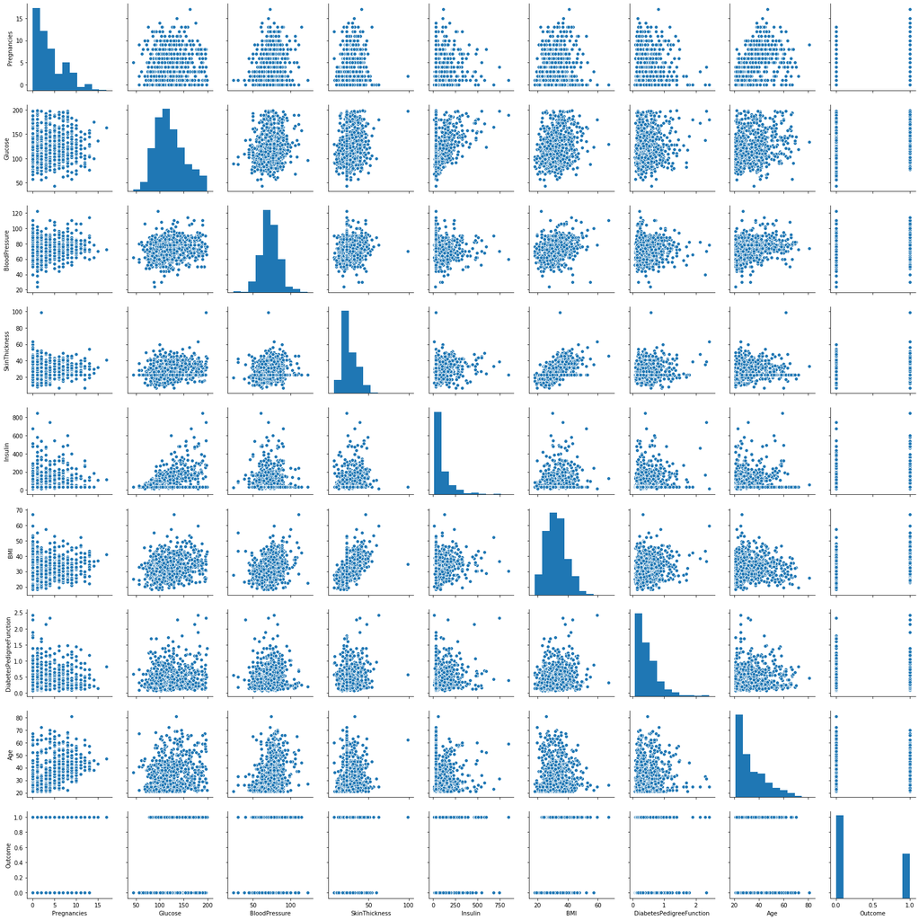

```python
sns.pairplot(pima_df)
```

```python
pima_df.corr()
```

|  | Pregnancies | Glucose | BloodPressure | SkinThickness | Insulin | BMI | DiabetesPedigreeFunction | Age | Outcome |
| --- | --- | --- | --- | --- | --- | --- | --- | --- | --- |
| Pregnancies | 1.000000 | 0.128213 | 0.208615 | 0.032568 | -0.055697 | 0.021546 | -0.033523 | 0.544341 | 0.221898 |
| Glucose | 0.128213 | 1.000000 | 0.218937 | 0.172143 | 0.357573 | 0.231400 | 0.137327 | 0.266909 | 0.492782 |
| BloodPressure | 0.208615 | 0.218937 | 1.000000 | 0.147809 | -0.028721 | 0.281132 | -0.002378 | 0.324915 | 0.165723 |
| SkinThickness | 0.032568 | 0.172143 | 0.147809 | 1.000000 | 0.238188 | 0.546951 | 0.142977 | 0.054514 | 0.189065 |
| Insulin | -0.055697 | 0.357573 | -0.028721 | 0.238188 | 1.000000 | 0.189022 | 0.178029 | -0.015413 | 0.148457 |
| BMI | 0.021546 | 0.231400 | 0.281132 | 0.546951 | 0.189022 | 1.000000 | 0.153506 | 0.025744 | 0.312249 |
| DiabetesPedigreeFunction | -0.033523 | 0.137327 | -0.002378 | 0.142977 | 0.178029 | 0.153506 | 1.000000 | 0.033561 | 0.173844 |
| Age | 0.544341 | 0.266909 | 0.324915 | 0.054514 | -0.015413 | 0.025744 | 0.033561 | 1.000000 | 0.238356 |
| Outcome | 0.221898 | 0.492782 | 0.165723 | 0.189065 | 0.148457 | 0.312249 | 0.173844 | 0.238356 | 1.000000 |

```python
#Outcome has high correlation with Glucose, BMI and Age variables
#Pregnancies, Glucose and BloodPressure are correlated with Age
```

# Q8 Split the pima_df into training and test set in the ratio of 70:30 (Training:Test).</b>

```python
X = pima_df.drop("Outcome", axis=1)
y = pima_df["Outcome"]
```

```python
test_size = 0.30 # taking 70:30 training and test set
seed = 7  # Random numbmer seeding for reapeatability of the code
X_train, X_test, y_train, y_test = train_test_split(X, y, test_size=test_size, random_state=seed)
```

# Q9 Create the decision tree model using “entropy” method of reducing the entropy and fit it to training data.</b>

```python
dt_model = DecisionTreeClassifier(criterion = 'entropy' )
dt_model.fit(X_train, y_train)
```

```
DecisionTreeClassifier(class_weight=None, criterion='entropy', max_depth=None,
                       max_features=None, max_leaf_nodes=None,
                       min_impurity_decrease=0.0, min_impurity_split=None,
                       min_samples_leaf=1, min_samples_split=2,
                       min_weight_fraction_leaf=0.0, presort=False,
                       random_state=None, splitter='best')
```

# Q10 Print the accuracy of the model & print the confusion matrix

```python
dt_model.score(X_test , y_test)
```

```
0.7359307359307359
```

```python
y_predict = dt_model.predict(X_test)
print(metrics.confusion_matrix(y_test, y_predict))
```

```
[[114  33]
 [ 28  56]]
```

# Q11 Print the feature importance of the decision model

```python
print(dt_model.feature_importances_)
```

```
[0.06118398 0.3066049  0.06354449 0.07156265 0.05131636 0.1720578
 0.13188968 0.14184015]
```

# Q12 Apply the Random forest model and print the accuracy of Random forest Model

```python
from sklearn.ensemble import RandomForestClassifier
rfcl = RandomForestClassifier(n_estimators = 85)
rfcl = rfcl.fit(X_train, y_train)
```

```python
rfcl.score(X_test,y_test)
```

```
0.7835497835497836
```

# Q13 Apply Adaboost Ensemble Algorithm for the same data and print the accuracy.

```python
from sklearn.ensemble import AdaBoostClassifier
```

```python
ada_clf = AdaBoostClassifier(DecisionTreeClassifier(max_depth=1),
                             n_estimators=100,
                             algorithm='SAMME',
                             learning_rate=1)

ada_clf.fit(X_train, y_train)
```

```
AdaBoostClassifier(algorithm='SAMME',
                   base_estimator=DecisionTreeClassifier(class_weight=None,
                                                         criterion='gini',
                                                         max_depth=1,
                                                         max_features=None,
                                                         max_leaf_nodes=None,
                                                         min_impurity_decrease=0.0,
                                                         min_impurity_split=None,
                                                         min_samples_leaf=1,
                                                         min_samples_split=2,
                                                         min_weight_fraction_leaf=0.0,
                                                         presort=False,
                                                         random_state=None,
                                                         splitter='best'),
                   learning_rate=1, n_estimators=100, random_state=None)
```

```python
y_pred = ada_clf.predict(X_test)
```

```python
from sklearn.metrics import accuracy_score

accuracy_score(y_test, y_pred)
```

```
0.7662337662337663
```

# Q14 - Apply Bagging Classifier Algorithm and print the accuracy.

```python
from sklearn.ensemble import BaggingClassifier
```

```python
bag_clf = BaggingClassifier(DecisionTreeClassifier(),
                            n_estimators = 400,
                            bootstrap = False,
                            max_samples = .7,
                            n_jobs = -1)
```

```python
bag_clf.fit(X_train, y_train)
```

```
BaggingClassifier(base_estimator=DecisionTreeClassifier(class_weight=None,
                                                        criterion='gini',
                                                        max_depth=None,
                                                        max_features=None,
                                                        max_leaf_nodes=None,
                                                        min_impurity_decrease=0.0,
                                                        min_impurity_split=None,
                                                        min_samples_leaf=1,
                                                        min_samples_split=2,
                                                        min_weight_fraction_leaf=0.0,
                                                        presort=False,
                                                        random_state=None,
                                                        splitter='best'),
                  bootstrap=False, bootstrap_features=False, max_features=1.0,
                  max_samples=0.7, n_estimators=400, n_jobs=-1, oob_score=False,
                  random_state=None, verbose=0, warm_start=False)
```

```python
bag_clf.score(X_test,y_test)
```

```
0.7532467532467533
```

```python
y_pred = bag_clf.predict(X_test)
accuracy_score(y_test, y_pred)
```

```
0.7532467532467533
```